# INDE498_HW1

# Question 1

Repeat the analysis shown in the R lab of this chapter, but use TOTAL13 as the outcome variable. Please build both the regression model and the decision tree model (for regression). Identify the final models you would select, evaluate the models, and compare the regression model with the tree model.

# Question 2

Find two data sets from the UCI data repository or R datasets. Conduct a detailed regression analysis for both datasets using both regression model and the tree model (for regression), e.g., for regression model, you may want to conduct model selection, model comparison, testing of the significance of the regression parameters, evaluation of the R-squared and significance of the model. Also comment on the application of your model on the context of the dataset you have selected.

## Car Dataset

The first dataset we chose for modeling is the cu.summary dataset that contains automobile data taken from the April, 1990 issue of “Consumer Reports”. The dataset contains 117 observations and 5 features. We are trying to predict the price of the car. A table of feature descriptions is provided below.

| Feature Name | Description |
| --- | --- |
| Price | a numeric vector giving the list price in US dollars of a standard model |
| Country | Country of origin |
| Reliability | an ordered factor with levels ‘Much worse’ < ‘worse’ < ‘average’ < ‘better’ < ‘Much better’ |
| Mileage | fuel consumption miles per US gallon |
| Type | a factor with levels Compact Large Medium Small Sporty Van |

### Linear Regression

```r
lm.car <- lm(Price~., data=df.car)
summary(lm.car)
```

```
##
## Call:
## lm(formula = Price ~ ., data = df.car)
##
## Residuals:
##     Min      1Q  Median      3Q     Max
## -3078.1 -1048.3     3.8   920.1  5341.2
##
## Coefficients:
##                        Estimate Std. Error t value Pr(>|t|)
## (Intercept)             18992.2     3389.0   5.604 3.42e-06 ***
## CountryJapan             1213.8     2719.7   0.446  0.65838
## CountryJapan/USA         -154.6     2756.3  -0.056  0.95562
## CountryKorea            -2203.6     2962.6  -0.744  0.46243
## CountryMexico           -3176.7     3298.4  -0.963  0.34272
## CountrySweden            5558.9     3164.0   1.757  0.08850 .
## CountryUSA              -2625.2     2566.9  -1.023  0.31411
## Reliabilitybetter        1853.7     1460.1   1.270  0.21340
## ReliabilityMuch better   -913.6     1452.3  -0.629  0.53377
## ReliabilityMuch worse    -415.1     1267.3  -0.328  0.74538
## Reliabilityworse         -822.7     1266.5  -0.650  0.52057
## Mileage                  -265.3      129.7  -2.044  0.04921 *
## TypeLarge                5140.8     1686.4   3.048  0.00459 **
## TypeMedium               5431.7     1070.7   5.073 1.61e-05 ***
## TypeSmall               -2100.3     1346.9  -1.559  0.12875
## TypeSporty                894.6     1282.7   0.697  0.49057
## TypeVan                  1723.1     1780.6   0.968  0.34045
## ---
## Signif. codes:  0 '***' 0.001 '**' 0.01 '*' 0.05 '.' 0.1 ' ' 1
##
## Residual standard error: 2091 on 32 degrees of freedom
##   (68 observations deleted due to missingness)
## Multiple R-squared:  0.837,  Adjusted R-squared:  0.7555
## F-statistic: 10.27 on 16 and 32 DF,  p-value: 1.899e-08
```

```r
lm.car <- stepAIC(lm.car, direction="both")
```

```
## Start:  AIC=762.39
## Price ~ Country + Reliability + Mileage + Type
##
##               Df Sum of Sq       RSS    AIC
## <none>                     139957482 762.39
## - Reliability  4  27132444 167089926 763.07
## - Mileage      1  18280336 158237818 766.40
## - Country      6  80914089 220871570 772.74
## - Type         5 168527460 308484942 791.11
```

```r
summary(lm.car)
```

```
##
## Call:
## lm(formula = Price ~ Country + Reliability + Mileage + Type,
##     data = df.car)
##
## Residuals:
##     Min      1Q  Median      3Q     Max
## -3078.1 -1048.3     3.8   920.1  5341.2
##
## Coefficients:
##                        Estimate Std. Error t value Pr(>|t|)
## (Intercept)             18992.2     3389.0   5.604 3.42e-06 ***
## CountryJapan             1213.8     2719.7   0.446  0.65838
## CountryJapan/USA         -154.6     2756.3  -0.056  0.95562
## CountryKorea            -2203.6     2962.6  -0.744  0.46243
## CountryMexico           -3176.7     3298.4  -0.963  0.34272
## CountrySweden            5558.9     3164.0   1.757  0.08850 .
## CountryUSA              -2625.2     2566.9  -1.023  0.31411
## Reliabilitybetter        1853.7     1460.1   1.270  0.21340
## ReliabilityMuch better   -913.6     1452.3  -0.629  0.53377
## ReliabilityMuch worse    -415.1     1267.3  -0.328  0.74538
## Reliabilityworse         -822.7     1266.5  -0.650  0.52057
## Mileage                  -265.3      129.7  -2.044  0.04921 *
## TypeLarge                5140.8     1686.4   3.048  0.00459 **
## TypeMedium               5431.7     1070.7   5.073 1.61e-05 ***
## TypeSmall               -2100.3     1346.9  -1.559  0.12875
## TypeSporty                894.6     1282.7   0.697  0.49057
## TypeVan                  1723.1     1780.6   0.968  0.34045
## ---
## Signif. codes:  0 '***' 0.001 '**' 0.01 '*' 0.05 '.' 0.1 ' ' 1
##
## Residual standard error: 2091 on 32 degrees of freedom
##   (68 observations deleted due to missingness)
## Multiple R-squared:  0.837,  Adjusted R-squared:  0.7555
## F-statistic: 10.27 on 16 and 32 DF,  p-value: 1.899e-08
```

### Decision Tree

```r
tr.car <- rpart(Price~., data=df.car)
#prp(tr.car, nn.cex=1)
```

## Males Dataset

The second dataset we chose for modeling is the Males dataset that recorded data about the wages and education of young males. The dataset contained 4360 observations and 12 features. We are trying to predict the wage of the person. A table of feature descriptions is provided below.

| Feature Name | Description |
| --- | --- |
| nr | unique identifier |
| year | year data was collected |
| school | years of schooling |
| exper | years of experience |
| union | wage set by collective bargaining? |
| ethn | ethnicity |
| married | are they married? |
| health | health problems? |
| wage | log of hourly wage |
| industry | work industry |
| occupation | job occupation |
| residence | area of residence |

### Linear Regression

We first fit an initial linear regression model with all of the features to predict the wage of the individual. From looking at the summary, the initial linear regression model is able to explain 28.54% of the variability of the wage.

```r
lm.males <- lm(wage~., data=df.males)
summary(lm.males)
```

```
##
## Call:
## lm(formula = wage ~ ., data = df.males)
##
## Residuals:
##     Min      1Q  Median      3Q     Max
## -5.1929 -0.2273  0.0220  0.2561  2.2798
##
## Coefficients:
##                                                 Estimate Std. Error
## (Intercept)                                   -5.833e+01  1.487e+01
## nr                                            -6.947e-06  2.662e-06
## year                                           2.956e-02  7.531e-03
## school                                         7.606e-02  6.392e-03
## exper                                          1.747e-02  6.667e-03
## unionyes                                       1.786e-01  2.030e-02
## ethnhisp                                       9.737e-02  3.459e-02
## ethnother                                      1.136e-01  2.621e-02
## marriedyes                                     8.674e-02  1.789e-02
## healthyes                                     -5.440e-02  6.555e-02
## industryBusiness_and_Repair_Service            2.331e-01  6.763e-02
## industryConstruction                           3.289e-01  6.845e-02
## industryEntertainment                         -1.460e-01  9.023e-02
## industryFinance                                4.802e-01  7.562e-02
## industryManufacturing                          3.794e-01  6.250e-02
## industryMining                                 4.424e-01  9.611e-02
## industryPersonal_Service                       1.970e-01  8.613e-02
## industryProfessional_and_Related Service       6.675e-02  6.815e-02
## industryPublic_Administration                  2.886e-01  7.313e-02
## industryTrade                                  1.460e-01  6.287e-02
## industryTransportation                         4.441e-01  6.743e-02
## occupationCraftsmen, Foremen_and_kindred       5.664e-02  3.163e-02
## occupationFarm_Laborers_and_Foreman            8.437e-03  9.345e-02
## occupationLaborers_and_farmers                -3.519e-02  3.710e-02
## occupationManagers, Officials_and_Proprietors  1.448e-01  3.613e-02
## occupationOperatives_and_kindred              -3.784e-02  3.229e-02
## occupationProfessional, Technical_and_kindred  1.723e-01  3.583e-02
## occupationSales_Workers                        6.680e-02  4.391e-02
## occupationService_Workers                     -5.467e-02  3.419e-02
## residencenothern_central                      -1.455e-01  2.286e-02
```

[output cut: 27 more lines]

```
## occupationManagers, Officials_and_Proprietors   4.008 6.27e-05 ***
## occupationOperatives_and_kindred               -1.172 0.241450
## occupationProfessional, Technical_and_kindred   4.808 1.60e-06 ***
## occupationSales_Workers                         1.521 0.128310
## occupationService_Workers                      -1.599 0.109933
## residencenothern_central                       -6.366 2.22e-10 ***
## residencerural_area                            -1.912 0.055923 .
## residencesouth                                 -5.723 1.15e-08 ***
## ---
## Signif. codes:  0 '***' 0.001 '**' 0.01 '*' 0.05 '.' 0.1 ' ' 1
##
## Residual standard error: 0.4523 on 3083 degrees of freedom
##   (1245 observations deleted due to missingness)
## Multiple R-squared:  0.2854, Adjusted R-squared:  0.2782
## F-statistic: 39.72 on 31 and 3083 DF,  p-value: < 2.2e-16
```

Next we used some feature selection using stepwise regresssion to fit the best model. The final model produced from the stepwise regression found all but the health feature to be signficant. By analyzing the difference in the models, we can see that the R-squared was only reduced to 28.53%.

```r
lm.males <- stepAIC(lm.males, direction="both")
```

```
## Start:  AIC=-4910.9
## wage ~ nr + year + school + exper + union + ethn + married +
##     health + industry + occupation + residence
##
##              Df Sum of Sq    RSS     AIC
## - health      1     0.141 630.89 -4912.2
## <none>                    630.75 -4910.9
## - nr          1     1.394 632.14 -4906.0
## - exper       1     1.405 632.15 -4906.0
## - year        1     3.152 633.90 -4897.4
## - ethn        2     3.879 634.63 -4895.8
## - married     1     4.809 635.56 -4889.2
## - residence   3     9.557 640.30 -4870.1
## - occupation  8    15.155 645.90 -4852.9
## - union       1    15.827 646.57 -4835.7
## - school      1    28.968 659.71 -4773.0
## - industry   11    50.919 681.67 -4691.1
##
## Step:  AIC=-4912.21
## wage ~ nr + year + school + exper + union + ethn + married +
##     industry + occupation + residence
##
##              Df Sum of Sq    RSS     AIC
## <none>                    630.89 -4912.2
## + health      1     0.141 630.75 -4910.9
## - nr          1     1.389 632.28 -4907.4
## - exper       1     1.417 632.30 -4907.2
## - year        1     3.155 634.04 -4898.7
## - ethn        2     3.862 634.75 -4897.2
## - married     1     4.785 635.67 -4890.7
## - residence   3     9.567 640.45 -4871.3
## - occupation  8    15.338 646.23 -4853.4
## - union       1    16.019 646.91 -4836.1
## - school      1    29.104 659.99 -4773.7
## - industry   11    50.937 681.82 -4692.3
```

```r
summary(lm.males)
```

```
##
## Call:
## lm(formula = wage ~ nr + year + school + exper + union + ethn +
##     married + industry + occupation + residence, data = df.males)
##
## Residuals:
##     Min      1Q  Median      3Q     Max
## -5.1925 -0.2273  0.0224  0.2568  2.2815
##
## Coefficients:
##                                                 Estimate Std. Error
## (Intercept)                                   -5.836e+01  1.487e+01
## nr                                            -6.937e-06  2.662e-06
## year                                           2.957e-02  7.531e-03
## school                                         7.621e-02  6.389e-03
## exper                                          1.754e-02  6.666e-03
## unionyes                                       1.794e-01  2.028e-02
## ethnhisp                                       9.749e-02  3.459e-02
## ethnother                                      1.133e-01  2.620e-02
## marriedyes                                     8.652e-02  1.789e-02
## industryBusiness_and_Repair_Service            2.349e-01  6.760e-02
## industryConstruction                           3.316e-01  6.837e-02
## industryEntertainment                         -1.451e-01  9.022e-02
## industryFinance                                4.822e-01  7.558e-02
## industryManufacturing                          3.814e-01  6.245e-02
## industryMining                                 4.450e-01  9.605e-02
## industryPersonal_Service                       1.984e-01  8.611e-02
## industryProfessional_and_Related Service       6.897e-02  6.810e-02
## industryPublic_Administration                  2.905e-01  7.309e-02
## industryTrade                                  1.485e-01  6.279e-02
## industryTransportation                         4.458e-01  6.739e-02
## occupationCraftsmen, Foremen_and_kindred       5.734e-02  3.162e-02
## occupationFarm_Laborers_and_Foreman            1.046e-02  9.341e-02
## occupationLaborers_and_farmers                -3.476e-02  3.710e-02
## occupationManagers, Officials_and_Proprietors  1.458e-01  3.611e-02
## occupationOperatives_and_kindred              -3.779e-02  3.229e-02
## occupationProfessional, Technical_and_kindred  1.732e-01  3.580e-02
## occupationSales_Workers                        6.662e-02  4.391e-02
## occupationService_Workers                     -5.474e-02  3.419e-02
## residencenothern_central                      -1.457e-01  2.285e-02
```

[output cut: 26 more lines]

```
## occupationManagers, Officials_and_Proprietors   4.038 5.53e-05 ***
## occupationOperatives_and_kindred               -1.170 0.242006
## occupationProfessional, Technical_and_kindred   4.839 1.37e-06 ***
## occupationSales_Workers                         1.517 0.129320
## occupationService_Workers                      -1.601 0.109440
## residencenothern_central                       -6.375 2.10e-10 ***
## residencerural_area                            -1.905 0.056834 .
## residencesouth                                 -5.719 1.17e-08 ***
## ---
## Signif. codes:  0 '***' 0.001 '**' 0.01 '*' 0.05 '.' 0.1 ' ' 1
##
## Residual standard error: 0.4523 on 3084 degrees of freedom
##   (1245 observations deleted due to missingness)
## Multiple R-squared:  0.2853, Adjusted R-squared:  0.2783
## F-statistic: 41.03 on 30 and 3084 DF,  p-value: < 2.2e-16
```

After obtaining this final model, we need to analyze the residual vs fitted plot and the QQ-plot to see if any of the linear regression assumptions are violated.

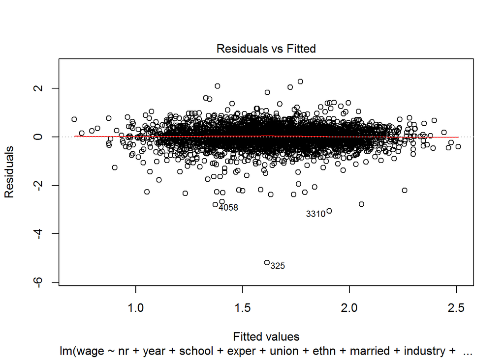

```r
plot(lm.males, which=c(1))
```

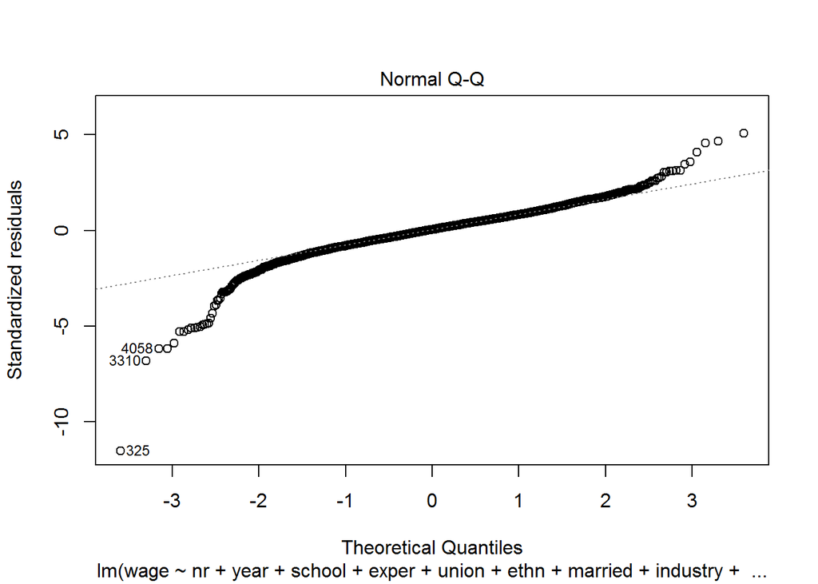

```r
plot(lm.males, which=c(2))
```

### Decision Tree

```r
tr.males <- rpart(wage~.,data=df.males)
```

# Question 5

Build a decision tree model based on the following dataset. Don’t use R. Use your pen and paper, and show the process.

```r
df.q5 <- data.frame(x1=c(0.22,0.58,0.57,0.41,0.60,0.12,0.25,0.32),
                    x2=c(0.38,0.32,0.28,0.43,0.29,0.32,0.32,0.38),
                    y=factor(c("No","Yes","Yes","Yes","No","Yes","Yes","No")))
```

We chose an arbitrary rule of splitting on the 4 quantiles. The first split is on x2 at the 3rd quantile, which is $x2 \leq 0.38$. The left node will contain data points (1,2,3,5,6,7,8) and the right node will contain data point (4).

$$e_{root} = -\frac{5}{8} log_{2}\frac{5}{8} - \frac{3}{8} log_{2}\frac{3}{8} = 0.9544$$
$$e_{x2 \leq 0.38} = -\frac{4}{7} log_{2}\frac{4}{7} - \frac{3}{7} log_{2}\frac{3}{7} = 0.9852$$
$$e_{x2 \gt 0.38} -\frac{1}{1} log_{2}\frac{1}{1} - \frac{0}{1} log_{2}\frac{0}{1} = 0$$
$$IG = e_{root} - \frac{7}{8}*e_{x2 \leq 0.38}-\frac{1}{8}*e_{x2 \gt 0.38} = 0.0924$$

The second split was done on left node containing data points (1,2,3,5,6,7,8) on x2 at the 3rd quantile, which is $x2 \leq 0.35$. The left node will contain data points (2,3,5,6,7) and the right node will contain data points (1,8).

$$e_{root} = -\frac{4}{7} log_{2}\frac{4}{7} - \frac{3}{7} log_{2}\frac{3}{7} = 0.9852$$
$$e_{x2 \leq 0.35} = -\frac{4}{5} log_{2}\frac{4}{5} - \frac{1}{5} log_{2}\frac{1}{5} = 0.7219$$
$$e_{x2 \gt 0.35} -\frac{0}{2} log_{2}\frac{0}{2} - \frac{2}{2} log_{2}\frac{2}{2} = 0$$
$$IG = e_{root} - \frac{5}{7}*e_{x2 \leq 0.35}-\frac{2}{7}*e_{x2 \gt 0.35} = 0.4696$$

The third split was on the left node containin data points (2,3,5,6,7) on x1 at the 3rd quantile, which is $x1 \leq 0.58$. The left node will contain data points (2,3,6,7) and the right node will contain data point (5).

$$e_{root} = -\frac{4}{5} log_{2}\frac{4}{5} - \frac{1}{5} log_{2}\frac{1}{5} = 0.7219$$
$$e_{x1 \leq 0.58} = -\frac{4}{4} log_{2}\frac{4}{4} - \frac{0}{4} log_{2}\frac{0}{4} = 0$$
$$e_{x1 \gt 0.58} -\frac{0}{1} log_{2}\frac{0}{1} - \frac{1}{1} log_{2}\frac{1}{1} = 0$$
$$IG = e_{root} - \frac{4}{5}*e_{x1 \leq 0.58}-\frac{1}{5}*e_{x1 \gt 0.58} = 0.7219$$

# Question 6

Write your own R script to implement the least squares estimation of a regression model. Compare the output from your script with the output from lm().

We arbitrarily choose the number of input variables as p = 3, and define the following function.

```r
#least_squares: Returns the least squares estimation of a regression model
least_squares <- function(x1, x2, x3, y){

  # Creating the X and Y matrices
  x_matrix = as.matrix(cbind(rep(1, 20), x1, x2, x3))
  y_matrix = as.matrix(y)

  # Computing the beta estimator
  beta_estimator = solve( t(x_matrix) %*% x_matrix ) %*% t(x_matrix) %*% y_matrix

  return(beta_estimator)
}
```

We can now compare our function against the output from lm()

```r
# Choose random x1, x2, x3 inputs
x1 = runif(1:20)
x2 = runif(1:20)
x3 = runif(1:20)

# Create an arbitrary y
y = 4 + 2*x1 + 1*x2 + 8*x3

# Call our function: least_squares
least_squares(x1, x2, x3, y)
```

```
##    [,1]
##       4
## x1    2
## x2    1
## x3    8
```

```r
# Calling the R function for linear regression: lm
lm(y~., data = data.frame(x1, x2, x3, y))
```

```
##
## Call:
## lm(formula = y ~ ., data = data.frame(x1, x2, x3, y))
##
## Coefficients:
## (Intercept)           x1           x2           x3
##           4            2            1            8
```